# Chapter 2 - Generalized Linear Models

# Resistivity Data (Gamma Distribution)

```r
# Create dataframe for Resistivity data
res <- data.frame("y" = c(193.4,247.6,168.2,205.0,303.4,339.9,226.3,208.3,
                          220.0,256.4,165.7,203.5,285.0,268.0,169.1,208.5),
                  "x1" = rep(c(-1,1),8),
                  "x2" = rep(c(-1,-1,1,1),4),
                  "x3" = rep(c(rep(-1,4),rep(1,4)),2),
                  "x4" = c(rep(-1,8),rep(1,8)))

res
```

| y | x1 | x2 | x3 | x4 |
| --- | --- | --- | --- | --- |
| 193.4 | -1 | -1 | -1 | -1 |
| 247.6 | 1 | -1 | -1 | -1 |
| 168.2 | -1 | 1 | -1 | -1 |
| 205.0 | 1 | 1 | -1 | -1 |
| 303.4 | -1 | -1 | 1 | -1 |
| 339.9 | 1 | -1 | 1 | -1 |
| 226.3 | -1 | 1 | 1 | -1 |
| 208.3 | 1 | 1 | 1 | -1 |
| 220.0 | -1 | -1 | -1 | 1 |
| 256.4 | 1 | -1 | -1 | 1 |

[output cut: 6 more lines]

## Using the Canonical Link (reciprocal)

By default, R uses the canonical link, in this case of Gamma, is `family=Gamma(link="inverse")`

```r
Gafit1 <- glm2(y~x1+x2+x3+x4, family = Gamma, data=res)
summary(Gafit1)
```

```
Call:
glm2(formula = y ~ x1 + x2 + x3 + x4, family = Gamma, data = res)

Deviance Residuals:
      Min         1Q     Median         3Q        Max
-0.165749  -0.051452   0.003529   0.071213   0.113935

Coefficients:
              Estimate Std. Error t value Pr(>|t|)
(Intercept)  0.0045204  0.0001161  38.919  3.9e-13 ***
x1          -0.0002378  0.0001090  -2.181 0.051752 .
x2           0.0006722  0.0001136   5.918 0.000101 ***
x3          -0.0004074  0.0001104  -3.691 0.003560 **
x4           0.0001331  0.0001085   1.227 0.245574
---
Signif. codes:  0 ‘***’ 0.001 ‘**’ 0.01 ‘*’ 0.05 ‘.’ 0.1 ‘ ’ 1

(Dispersion parameter for Gamma family taken to be 0.01022894)

    Null deviance: 0.69784  on 15  degrees of freedom
Residual deviance: 0.11540  on 11  degrees of freedom
AIC: 151.73

Number of Fisher Scoring iterations: 4
```

This implies the following fitted model:

$$\hat{\mu} = \frac{1}{0.0045-0.0002x_1 + 0.0007x_2 - 0.0004x_3 + 0.0001x_4}$$

- Increase in x1 and x3 result in higher mu
- Increase in x2 and x4 result in lower mu
- Hard to interpret the parameters

## Using the **log-link**

```r
Gafit2 <- glm2(y~x1+x2+x3+x4, family = Gamma(link="log"), data = res)
summary(Gafit2)
```

```
Call:
glm2(formula = y ~ x1 + x2 + x3 + x4, family = Gamma(link = "log"),
    data = res)

Deviance Residuals:
     Min        1Q    Median        3Q       Max
-0.17548  -0.06486   0.01423   0.08399   0.10898

Coefficients:
            Estimate Std. Error t value Pr(>|t|)
(Intercept)  5.41697    0.02619 206.826  < 2e-16 ***
x1           0.06058    0.02619   2.313 0.041090 *
x2          -0.15024    0.02619  -5.736 0.000131 ***
x3           0.08989    0.02619   3.432 0.005601 **
x4          -0.02878    0.02619  -1.099 0.295248
---
Signif. codes:  0 ‘***’ 0.001 ‘**’ 0.01 ‘*’ 0.05 ‘.’ 0.1 ‘ ’ 1

(Dispersion parameter for Gamma family taken to be 0.01097542)

    Null deviance: 0.69784  on 15  degrees of freedom
Residual deviance: 0.12418  on 11  degrees of freedom
AIC: 152.91

Number of Fisher Scoring iterations: 4
```

The fitted model is now:

$$\hat{\mu} = e^{5.4170 + 0.0606x_1 - 0.15024x_2 + 0.0899x_3 - 0.0288x_4 }$$

- An increase in x1 from -1 to 1 (2 units) will hence be $e^{2(0.0606)} = 1.129 $
- Increase of mu by 13%
- Also note that the dispersion, $\psi = 0.011$

## Dispersion Paramter

`glm` only provides crude fit of $\psi$ using the MME. To compute using the MLE, need to use the `MASS` package.

```r
g <- gamma.shape(Gafit2) ; g
```

```
Alpha: 129.01090
SE:     45.55343
```

- This implies that $\hat{r} = 129.01$ and $\psi = \frac{1}{\hat{r}}$
- Hence, $\psi = \frac{1}{129.01} = 0.007751$

Verify below:

```r
d <- gamma.dispersion(Gafit2) ; d
```

```
[1] 0.007751283
```

### Scaled Deviance

$$SD = \frac{Residual Deviance}{\hat{\psi}}$$

```r
sd <- Gafit2$deviance / d; sd
```

```
[1] 16.02067
```

### Fitness

```r
sd / Gafit2$df.residual
```

```
[1] 1.456425
```

- Close to one implies no lack of fit

## Two Factor Interaction

```r
Gafit3 <- glm2(y~(x1+x2+x3+x4)*(x1+x2+x3+x4),
               family = Gamma(link = "log"), data = res)

summary(Gafit3)
```

```
Call:
glm2(formula = y ~ (x1 + x2 + x3 + x4) * (x1 + x2 + x3 + x4),
    family = Gamma(link = "log"), data = res)

Deviance Residuals:
        1          2          3          4          5          6
-0.042660   0.017512   0.016572   0.007758  -0.029264   0.052499
        7          8          9         10         11         12
 0.053416  -0.080985   0.032802  -0.008745  -0.007790  -0.016766
       13         14         15         16
 0.037406  -0.063659  -0.064652   0.085267

Coefficients:
             Estimate Std. Error t value Pr(>|t|)
(Intercept)  5.414146   0.020556 263.379  1.5e-11 ***
x1           0.061662   0.020556   3.000 0.030112 *
x2          -0.149640   0.020556  -7.279 0.000765 ***
x3           0.090030   0.020556   4.380 0.007157 **
x4          -0.027982   0.020556  -1.361 0.231578
x1:x2        0.005002   0.020556   0.243 0.817425
x1:x3       -0.038620   0.020556  -1.879 0.119073
x1:x4        0.001966   0.020556   0.096 0.927507
x2:x3       -0.044111   0.020556  -2.146 0.084689 .
x2:x4       -0.010981   0.020556  -0.534 0.616086
x3:x4       -0.045606   0.020556  -2.219 0.077269 .
---
Signif. codes:  0 ‘***’ 0.001 ‘**’ 0.01 ‘*’ 0.05 ‘.’ 0.1 ‘ ’ 1

(Dispersion parameter for Gamma family taken to be 0.006761097)

    Null deviance: 0.697837  on 15  degrees of freedom
Residual deviance: 0.033882  on  5  degrees of freedom
AIC: 144.11

Number of Fisher Scoring iterations: 4
```

```r
drop1(Gafit3, test = "LR")
```

```
Single term deletions

Model:
y ~ (x1 + x2 + x3 + x4) * (x1 + x2 + x3 + x4)
       Df Deviance    AIC scaled dev. Pr(>Chi)
<none>    0.033882 144.11
x1:x2   1 0.034281 142.17      0.0591  0.80793
x1:x3   1 0.057723 145.64      3.5262  0.06041 .
x1:x4   1 0.033944 142.12      0.0091  0.92387
x2:x3   1 0.064983 146.71      4.6000  0.03197 *
x2:x4   1 0.035808 142.40      0.2848  0.59356
x3:x4   1 0.067121 147.03      4.9162  0.02661 *
---
Signif. codes:  0 ‘***’ 0.001 ‘**’ 0.01 ‘*’ 0.05 ‘.’ 0.1 ‘ ’ 1
```

### Removing Insignificant Interactions

- Also using the estimated dispersion, $\psi$ from the `MASS` package.

```r
Gafit4 <- glm2(y~x1+x2+x3+x4+x1:x3+x2:x3+x3:x4,
               family = Gamma(link = "log"), data = res)

summary.Gafit4<-summary(Gafit4, dispersion = gamma.dispersion(Gafit4))
summary.Gafit4
```

```
Call:
glm2(formula = y ~ x1 + x2 + x3 + x4 + x1:x3 + x2:x3 + x3:x4,
    family = Gamma(link = "log"), data = res)

Deviance Residuals:
      Min         1Q     Median         3Q        Max
-0.083185  -0.036793  -0.000648   0.038199   0.081390

Coefficients:
            Estimate Std. Error z value Pr(>|z|)
(Intercept)  5.41422    0.01190 454.978  < 2e-16 ***
x1           0.06127    0.01190   5.149 2.62e-07 ***
x2          -0.14957    0.01190 -12.569  < 2e-16 ***
x3           0.08994    0.01190   7.558 4.09e-14 ***
x4          -0.02780    0.01190  -2.336 0.019480 *
x1:x3       -0.03887    0.01190  -3.267 0.001088 **
x2:x3       -0.04407    0.01190  -3.703 0.000213 ***
x3:x4       -0.04549    0.01190  -3.822 0.000132 ***
---
Signif. codes:  0 ‘***’ 0.001 ‘**’ 0.01 ‘*’ 0.05 ‘.’ 0.1 ‘ ’ 1

(Dispersion parameter for Gamma family taken to be 0.002265746)

    Null deviance: 0.697837  on 15  degrees of freedom
Residual deviance: 0.036266  on  8  degrees of freedom
AIC: 139.2

Number of Fisher Scoring iterations: 4
```

- If interaction is significant and main is not, we try not to remove the main.

### Scaled Deviance

```r
sd <- Gafit4$deviance / gamma.dispersion(Gafit4); sd
```

```
[1] 16.00604
```

### Fitness

```r
sd / Gafit4$df.residual
```

```
[1] 2.000755
```

- 2 >> 1 , hence, there is underfit

## Deviance Residual Plot

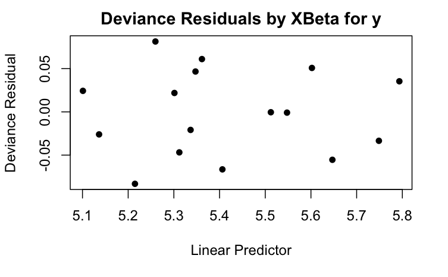

```r
# Construct deviance residual plot
plot(Gafit4$linear.predictor, residuals(Gafit4, "deviance"),
     pch = 16, main = "Deviance Residuals by XBeta for y",
     xlab = "Linear Predictor", ylab = "Deviance Residual")
```

- Components of deviance contributed by each observation
- Points should fall randomly on both sides of zero, no systematic relationship
- Else, there is a systematic relationship between response and independent varibles not captured yet.

# Attendance Data

```r
atd <- read_csv("/Users/jasonchan/MSTAT/STAT6014_Advanced_Stat_Model/Lecture codes/R codes and data for Chapter 2 examples-20200202/attendance.csv")
# Set factor variables
atd$gender <- as.factor(atd$gender)
atd$prog <- relevel(as.factor(atd$prog),ref='3')

atd
```

| sid | gender | math | daysabs | prog |
| --- | --- | --- | --- | --- |
| 1001 | 2 | 63 | 4 | 2 |
| 1002 | 2 | 27 | 4 | 2 |
| 1003 | 1 | 20 | 2 | 2 |
| 1004 | 1 | 16 | 3 | 2 |
| 1005 | 1 | 2 | 3 | 2 |
| 1006 | 1 | 71 | 13 | 2 |
| 1007 | 1 | 63 | 11 | 2 |
| 1008 | 2 | 3 | 7 | 2 |
| 1009 | 2 | 51 | 10 | 2 |
| 1010 | 2 | 49 | 9 | 3 |

[output cut: 304 more lines]

## Poisson Attempt

```r
# Fit Poisson regression model
poifit <- glm2(daysabs~math+prog, family = poisson, data = atd)
summary(poifit)
```

```
Call:
glm2(formula = daysabs ~ math + prog, family = poisson, data = atd)

Deviance Residuals:
    Min       1Q   Median       3Q      Max
-4.2597  -2.2038  -0.9193   0.6511   7.4233

Coefficients:
             Estimate Std. Error z value Pr(>|z|)
(Intercept)  1.370610   0.078447  17.472  < 2e-16 ***
math        -0.006808   0.000931  -7.313 2.62e-13 ***
prog1        1.281364   0.077886  16.452  < 2e-16 ***
prog2        0.841467   0.067888  12.395  < 2e-16 ***
---
Signif. codes:  0 ‘***’ 0.001 ‘**’ 0.01 ‘*’ 0.05 ‘.’ 0.1 ‘ ’ 1

(Dispersion parameter for poisson family taken to be 1)

    Null deviance: 2217.7  on 313  degrees of freedom
Residual deviance: 1774.0  on 310  degrees of freedom
AIC: 2665.3

Number of Fisher Scoring iterations: 5
```

- Fitness of 1774 / 310 = 5.72 >> 1, underfit
- Due to the overdispersion of the dayabs

## Negative Binomial Distribution

$$Var(y | x) = \mu(1+a\mu)$$

- a or r is the dispersion parameter which controls severity of over dispersion

```r
nbfit <- glm.nb(daysabs~math+prog, link = log, data = atd)
summary(nbfit)
```

```
Call:
glm.nb(formula = daysabs ~ math + prog, data = atd, link = log,
    init.theta = 1.032713156)

Deviance Residuals:
    Min       1Q   Median       3Q      Max
-2.1547  -1.0192  -0.3694   0.2285   2.5273

Coefficients:
             Estimate Std. Error z value Pr(>|z|)
(Intercept)  1.336615   0.182864   7.309 2.68e-13 ***
math        -0.005993   0.002505  -2.392   0.0167 *
prog1        1.278651   0.200720   6.370 1.89e-10 ***
prog2        0.837891   0.144087   5.815 6.06e-09 ***
---
Signif. codes:  0 ‘***’ 0.001 ‘**’ 0.01 ‘*’ 0.05 ‘.’ 0.1 ‘ ’ 1

(Dispersion parameter for Negative Binomial(1.0327) family taken to be 1)

    Null deviance: 427.54  on 313  degrees of freedom
Residual deviance: 358.52  on 310  degrees of freedom
AIC: 1741.3

Number of Fisher Scoring iterations: 1

              Theta:  1.033
          Std. Err.:  0.106

 2 x log-likelihood:  -1731.258
```

$$log(\hat{\mu}) = 1.336 - 0.006math + 1.279I_{prog=1} + 0.838I_{prog=1}$$
* Students with lower math score, enrolled in program 1 or 2 are absent more

### LR Test

```r
# Type III analysis
drop1(nbfit, test="LR")
```

```
Single term deletions

Model:
daysabs ~ math + prog
       Df Deviance    AIC    LRT  Pr(>Chi)
<none>      358.52 1739.3
math    1   364.20 1742.9  5.677   0.01719 *
prog    2   407.35 1784.1 48.827 2.496e-11 ***
---
Signif. codes:  0 ‘***’ 0.001 ‘**’ 0.01 ‘*’ 0.05 ‘.’ 0.1 ‘ ’ 1
```

### Replicating the Negative Binomial in `glm2`

- Use back the r / theta = 1.0327 as input

```r
# Fit negative binomial regression model
# with known negative binomial dispersion parameter
# (note that the response distribution is in exponential family)
nbfit2 <- glm2(daysabs~math+prog, negative.binomial(1.0327, link="log"),
               data = atd)
summary(nbfit2, dispersion = 1)
```

```
Call:
glm2(formula = daysabs ~ math + prog, family = negative.binomial(1.0327,
    link = "log"), data = atd)

Deviance Residuals:
    Min       1Q   Median       3Q      Max
-2.1547  -1.0192  -0.3694   0.2285   2.5273

Coefficients:
             Estimate Std. Error z value Pr(>|z|)
(Intercept)  1.336613   0.182865   7.309 2.69e-13 ***
math        -0.005993   0.002505  -2.392   0.0167 *
prog1        1.278650   0.200721   6.370 1.89e-10 ***
prog2        0.837891   0.144088   5.815 6.06e-09 ***
---
Signif. codes:  0 ‘***’ 0.001 ‘**’ 0.01 ‘*’ 0.05 ‘.’ 0.1 ‘ ’ 1

(Dispersion parameter for Negative Binomial(1.0327) family taken to be 1)

    Null deviance: 427.54  on 313  degrees of freedom
Residual deviance: 358.52  on 310  degrees of freedom
AIC: 1739.3

Number of Fisher Scoring iterations: 5
```